# 5 What are transforms?

## 5.1 Motivation

In **Part I** of the book, we learned that our `GeoTable` representation of geospatial data provides the data access pattern of the `DataFrame`, a feature that is very convenient for data science. To recap, let’s consider the following geotable with four random variables:

```julia
N = 10000
a = [2randn(N÷2) .+ 6; randn(N÷2)]
b = [3randn(N÷2); 2randn(N÷2)]
c = randn(N)
d = c .+ 0.6randn(N)

table = (; a, b, c, d)

gtb = georef(table, CartesianGrid(100, 100))
```

9990 rows omitted

| 10000×5 GeoTable over 100×100 CartesianGrid a Continuous [NoUnits] | 10000×5 GeoTable over 100×100 CartesianGrid b Continuous [NoUnits] | 10000×5 GeoTable over 100×100 CartesianGrid c Continuous [NoUnits] | 10000×5 GeoTable over 100×100 CartesianGrid d Continuous [NoUnits] | 10000×5 GeoTable over 100×100 CartesianGrid geometry Quadrangle 🖈 Cartesian{NoDatum} |
| --- | --- | --- | --- | --- |
| 2.24254 | -3.22627 | 1.0496 | 2.40023 | Quadrangle((x: 0.0 m, y: 0.0 m), ..., (x: 0.0 m, y: 1.0 m)) |
| 4.03969 | -4.7222 | -0.676682 | -0.954163 | Quadrangle((x: 1.0 m, y: 0.0 m), ..., (x: 1.0 m, y: 1.0 m)) |
| 2.45896 | -1.05051 | -0.00873924 | -1.07302 | Quadrangle((x: 2.0 m, y: 0.0 m), ..., (x: 2.0 m, y: 1.0 m)) |
| 5.37619 | 0.877339 | -0.106737 | -0.149405 | Quadrangle((x: 3.0 m, y: 0.0 m), ..., (x: 3.0 m, y: 1.0 m)) |
| 5.83948 | -0.0414821 | 0.476349 | 0.219375 | Quadrangle((x: 4.0 m, y: 0.0 m), ..., (x: 4.0 m, y: 1.0 m)) |
| 6.00518 | -3.87105 | 0.93052 | -0.467425 | Quadrangle((x: 5.0 m, y: 0.0 m), ..., (x: 5.0 m, y: 1.0 m)) |
| 6.14868 | -1.86858 | 1.06582 | 1.07561 | Quadrangle((x: 6.0 m, y: 0.0 m), ..., (x: 6.0 m, y: 1.0 m)) |
| 5.25832 | -9.97965 | 1.53856 | 1.3701 | Quadrangle((x: 7.0 m, y: 0.0 m), ..., (x: 7.0 m, y: 1.0 m)) |
| 6.8722 | 3.18306 | 1.08043 | 1.4105 | Quadrangle((x: 8.0 m, y: 0.0 m), ..., (x: 8.0 m, y: 1.0 m)) |
| 10.1879 | -3.05472 | 0.143137 | 0.502531 | Quadrangle((x: 9.0 m, y: 0.0 m), ..., (x: 9.0 m, y: 1.0 m)) |
| ⋮ | ⋮ | ⋮ | ⋮ | ⋮ |

We can easily retrieve the “a” column of the geotable as a vector, and plot its histogram:

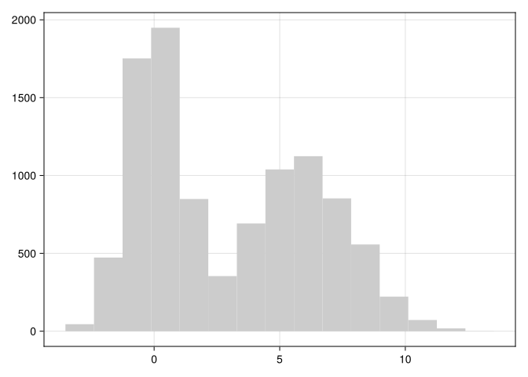

```julia
Mke.hist(gtb.a, color = "gray80")
```

We can compute the cross-correlation between columns “a” and “b”:

```julia
cor(gtb.a, gtb.b)
```

```
0.005081943653095415
```

And inspect bivariate distributions of the `values` of the geotable with PairPlots.jl by Thompson (2023):

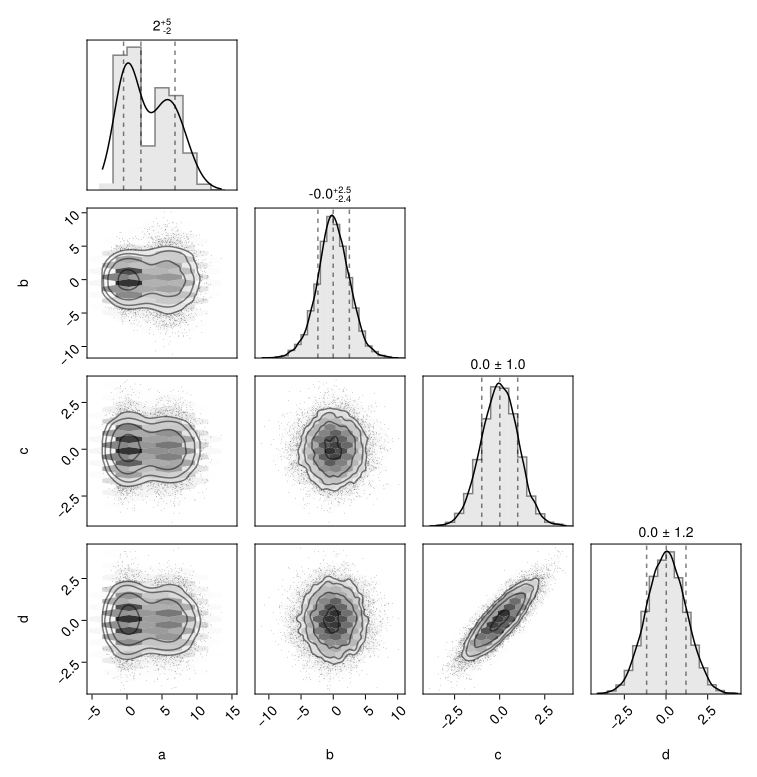

```julia
using PairPlots

pairplot(values(gtb))
```

This pattern is useful to answer geoscientific questions via marginal analysis (i.e. entire columns treated as measurements of a single random variable). However, the answers to many questions in geosciences depend on **where** the measurements were made.

Attempting to answer geoscientific questions with basic access to rows and columns can be very frustrating. In particular, this approach is prone to unintentional removal of geospatial information:

```julia
gtb.a
```

```
10000-element Vector{Float64}:
  2.2425374114987267
  4.0396925616811
  2.458958863972005
  5.376191676383771
  5.839482510115429
  6.005179096098923
  6.148683558252646
  5.258315793316808
  6.872203854535608
 10.18792067907215
  ⋮
  0.3112940398470766
  0.5145970680138676
 -1.0433613144651126
  0.34099213311772636
  0.23405463949975566
  0.576153468162224
  1.149284695910187
  1.1414100278812391
  1.6476278854955368
```

**Note**

Any script that is written in terms of direct column access has the potential to discard the special `geometry` column, and become unreadable very quickly with the use of auxiliary indices for rows.

We propose a new approach to geospatial data science with the concept of **transforms**, which we introduce in three classes with practical examples:

1. Feature transforms
2. Geometric transforms
3. Geospatial transforms

## 5.2 Feature transforms

A feature transform is a function that takes the `values` of the geotable and produces a new set of values over the same geospatial `domain`. The framework provides over 30 such transforms, ranging from basic selection of columns, to data cleaning, to advanced multivariate statistical transforms.

### 5.2.1 Basic

Let’s start with two basic and important transforms, `Select` and `Reject`. The `Select` transform can be used to select columns of interest from a geotable:

```julia
gtb |> Select("a", "b") # select columns "a" and "b"
```

9990 rows omitted

| 10000×3 GeoTable over 100×100 CartesianGrid a Continuous [NoUnits] | 10000×3 GeoTable over 100×100 CartesianGrid b Continuous [NoUnits] | 10000×3 GeoTable over 100×100 CartesianGrid geometry Quadrangle 🖈 Cartesian{NoDatum} |
| --- | --- | --- |
| 2.24254 | -3.22627 | Quadrangle((x: 0.0 m, y: 0.0 m), ..., (x: 0.0 m, y: 1.0 m)) |
| 4.03969 | -4.7222 | Quadrangle((x: 1.0 m, y: 0.0 m), ..., (x: 1.0 m, y: 1.0 m)) |
| 2.45896 | -1.05051 | Quadrangle((x: 2.0 m, y: 0.0 m), ..., (x: 2.0 m, y: 1.0 m)) |
| 5.37619 | 0.877339 | Quadrangle((x: 3.0 m, y: 0.0 m), ..., (x: 3.0 m, y: 1.0 m)) |
| 5.83948 | -0.0414821 | Quadrangle((x: 4.0 m, y: 0.0 m), ..., (x: 4.0 m, y: 1.0 m)) |
| 6.00518 | -3.87105 | Quadrangle((x: 5.0 m, y: 0.0 m), ..., (x: 5.0 m, y: 1.0 m)) |
| 6.14868 | -1.86858 | Quadrangle((x: 6.0 m, y: 0.0 m), ..., (x: 6.0 m, y: 1.0 m)) |
| 5.25832 | -9.97965 | Quadrangle((x: 7.0 m, y: 0.0 m), ..., (x: 7.0 m, y: 1.0 m)) |
| 6.8722 | 3.18306 | Quadrangle((x: 8.0 m, y: 0.0 m), ..., (x: 8.0 m, y: 1.0 m)) |
| 10.1879 | -3.05472 | Quadrangle((x: 9.0 m, y: 0.0 m), ..., (x: 9.0 m, y: 1.0 m)) |
| ⋮ | ⋮ | ⋮ |

In the example above, we selected the columns “a” and “b” explicitly, but `Select` has various methods for more flexible column selection:

```julia
gtb |> Select(1:3) # select columns 1 to 3
```

9990 rows omitted

| 10000×4 GeoTable over 100×100 CartesianGrid a Continuous [NoUnits] | 10000×4 GeoTable over 100×100 CartesianGrid b Continuous [NoUnits] | 10000×4 GeoTable over 100×100 CartesianGrid c Continuous [NoUnits] | 10000×4 GeoTable over 100×100 CartesianGrid geometry Quadrangle 🖈 Cartesian{NoDatum} |
| --- | --- | --- | --- |
| 2.24254 | -3.22627 | 1.0496 | Quadrangle((x: 0.0 m, y: 0.0 m), ..., (x: 0.0 m, y: 1.0 m)) |
| 4.03969 | -4.7222 | -0.676682 | Quadrangle((x: 1.0 m, y: 0.0 m), ..., (x: 1.0 m, y: 1.0 m)) |
| 2.45896 | -1.05051 | -0.00873924 | Quadrangle((x: 2.0 m, y: 0.0 m), ..., (x: 2.0 m, y: 1.0 m)) |
| 5.37619 | 0.877339 | -0.106737 | Quadrangle((x: 3.0 m, y: 0.0 m), ..., (x: 3.0 m, y: 1.0 m)) |
| 5.83948 | -0.0414821 | 0.476349 | Quadrangle((x: 4.0 m, y: 0.0 m), ..., (x: 4.0 m, y: 1.0 m)) |
| 6.00518 | -3.87105 | 0.93052 | Quadrangle((x: 5.0 m, y: 0.0 m), ..., (x: 5.0 m, y: 1.0 m)) |
| 6.14868 | -1.86858 | 1.06582 | Quadrangle((x: 6.0 m, y: 0.0 m), ..., (x: 6.0 m, y: 1.0 m)) |
| 5.25832 | -9.97965 | 1.53856 | Quadrangle((x: 7.0 m, y: 0.0 m), ..., (x: 7.0 m, y: 1.0 m)) |
| 6.8722 | 3.18306 | 1.08043 | Quadrangle((x: 8.0 m, y: 0.0 m), ..., (x: 8.0 m, y: 1.0 m)) |
| 10.1879 | -3.05472 | 0.143137 | Quadrangle((x: 9.0 m, y: 0.0 m), ..., (x: 9.0 m, y: 1.0 m)) |
| ⋮ | ⋮ | ⋮ | ⋮ |

```julia
gtb |> Select(r"[bcd]") # columns matching regular expression
```

9990 rows omitted

| 10000×4 GeoTable over 100×100 CartesianGrid b Continuous [NoUnits] | 10000×4 GeoTable over 100×100 CartesianGrid c Continuous [NoUnits] | 10000×4 GeoTable over 100×100 CartesianGrid d Continuous [NoUnits] | 10000×4 GeoTable over 100×100 CartesianGrid geometry Quadrangle 🖈 Cartesian{NoDatum} |
| --- | --- | --- | --- |
| -3.22627 | 1.0496 | 2.40023 | Quadrangle((x: 0.0 m, y: 0.0 m), ..., (x: 0.0 m, y: 1.0 m)) |
| -4.7222 | -0.676682 | -0.954163 | Quadrangle((x: 1.0 m, y: 0.0 m), ..., (x: 1.0 m, y: 1.0 m)) |
| -1.05051 | -0.00873924 | -1.07302 | Quadrangle((x: 2.0 m, y: 0.0 m), ..., (x: 2.0 m, y: 1.0 m)) |
| 0.877339 | -0.106737 | -0.149405 | Quadrangle((x: 3.0 m, y: 0.0 m), ..., (x: 3.0 m, y: 1.0 m)) |
| -0.0414821 | 0.476349 | 0.219375 | Quadrangle((x: 4.0 m, y: 0.0 m), ..., (x: 4.0 m, y: 1.0 m)) |
| -3.87105 | 0.93052 | -0.467425 | Quadrangle((x: 5.0 m, y: 0.0 m), ..., (x: 5.0 m, y: 1.0 m)) |
| -1.86858 | 1.06582 | 1.07561 | Quadrangle((x: 6.0 m, y: 0.0 m), ..., (x: 6.0 m, y: 1.0 m)) |
| -9.97965 | 1.53856 | 1.3701 | Quadrangle((x: 7.0 m, y: 0.0 m), ..., (x: 7.0 m, y: 1.0 m)) |
| 3.18306 | 1.08043 | 1.4105 | Quadrangle((x: 8.0 m, y: 0.0 m), ..., (x: 8.0 m, y: 1.0 m)) |
| -3.05472 | 0.143137 | 0.502531 | Quadrangle((x: 9.0 m, y: 0.0 m), ..., (x: 9.0 m, y: 1.0 m)) |
| ⋮ | ⋮ | ⋮ | ⋮ |

A convenient method is also provided to select and rename columns:

```julia
gtb |> Select("a" => "A", "b" => "B")
```

9990 rows omitted

| 10000×3 GeoTable over 100×100 CartesianGrid A Continuous [NoUnits] | 10000×3 GeoTable over 100×100 CartesianGrid B Continuous [NoUnits] | 10000×3 GeoTable over 100×100 CartesianGrid geometry Quadrangle 🖈 Cartesian{NoDatum} |
| --- | --- | --- |
| 2.24254 | -3.22627 | Quadrangle((x: 0.0 m, y: 0.0 m), ..., (x: 0.0 m, y: 1.0 m)) |
| 4.03969 | -4.7222 | Quadrangle((x: 1.0 m, y: 0.0 m), ..., (x: 1.0 m, y: 1.0 m)) |
| 2.45896 | -1.05051 | Quadrangle((x: 2.0 m, y: 0.0 m), ..., (x: 2.0 m, y: 1.0 m)) |
| 5.37619 | 0.877339 | Quadrangle((x: 3.0 m, y: 0.0 m), ..., (x: 3.0 m, y: 1.0 m)) |
| 5.83948 | -0.0414821 | Quadrangle((x: 4.0 m, y: 0.0 m), ..., (x: 4.0 m, y: 1.0 m)) |
| 6.00518 | -3.87105 | Quadrangle((x: 5.0 m, y: 0.0 m), ..., (x: 5.0 m, y: 1.0 m)) |
| 6.14868 | -1.86858 | Quadrangle((x: 6.0 m, y: 0.0 m), ..., (x: 6.0 m, y: 1.0 m)) |
| 5.25832 | -9.97965 | Quadrangle((x: 7.0 m, y: 0.0 m), ..., (x: 7.0 m, y: 1.0 m)) |
| 6.8722 | 3.18306 | Quadrangle((x: 8.0 m, y: 0.0 m), ..., (x: 8.0 m, y: 1.0 m)) |
| 10.1879 | -3.05472 | Quadrangle((x: 9.0 m, y: 0.0 m), ..., (x: 9.0 m, y: 1.0 m)) |
| ⋮ | ⋮ | ⋮ |

The `Reject` transform can be used to reject columns from a geotable that are not relevant for a given analysis. It supports the same column specification of `Select`:

```julia
gtb |> Reject("b") # reject column "b"
```

9990 rows omitted

| 10000×4 GeoTable over 100×100 CartesianGrid a Continuous [NoUnits] | 10000×4 GeoTable over 100×100 CartesianGrid c Continuous [NoUnits] | 10000×4 GeoTable over 100×100 CartesianGrid d Continuous [NoUnits] | 10000×4 GeoTable over 100×100 CartesianGrid geometry Quadrangle 🖈 Cartesian{NoDatum} |
| --- | --- | --- | --- |
| 2.24254 | 1.0496 | 2.40023 | Quadrangle((x: 0.0 m, y: 0.0 m), ..., (x: 0.0 m, y: 1.0 m)) |
| 4.03969 | -0.676682 | -0.954163 | Quadrangle((x: 1.0 m, y: 0.0 m), ..., (x: 1.0 m, y: 1.0 m)) |
| 2.45896 | -0.00873924 | -1.07302 | Quadrangle((x: 2.0 m, y: 0.0 m), ..., (x: 2.0 m, y: 1.0 m)) |
| 5.37619 | -0.106737 | -0.149405 | Quadrangle((x: 3.0 m, y: 0.0 m), ..., (x: 3.0 m, y: 1.0 m)) |
| 5.83948 | 0.476349 | 0.219375 | Quadrangle((x: 4.0 m, y: 0.0 m), ..., (x: 4.0 m, y: 1.0 m)) |
| 6.00518 | 0.93052 | -0.467425 | Quadrangle((x: 5.0 m, y: 0.0 m), ..., (x: 5.0 m, y: 1.0 m)) |
| 6.14868 | 1.06582 | 1.07561 | Quadrangle((x: 6.0 m, y: 0.0 m), ..., (x: 6.0 m, y: 1.0 m)) |
| 5.25832 | 1.53856 | 1.3701 | Quadrangle((x: 7.0 m, y: 0.0 m), ..., (x: 7.0 m, y: 1.0 m)) |
| 6.8722 | 1.08043 | 1.4105 | Quadrangle((x: 8.0 m, y: 0.0 m), ..., (x: 8.0 m, y: 1.0 m)) |
| 10.1879 | 0.143137 | 0.502531 | Quadrangle((x: 9.0 m, y: 0.0 m), ..., (x: 9.0 m, y: 1.0 m)) |
| ⋮ | ⋮ | ⋮ | ⋮ |

**Note**

Unlike direct column access, the `Select` and `Reject` transforms preserve geospatial information.

**NoteTip for all users**

The `Select` transform can be used in conjunction with the `viewer` to quickly visualize a specific variable:

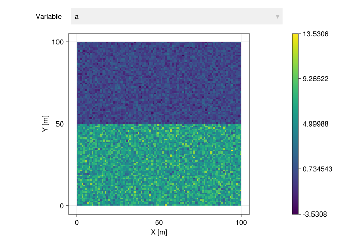

```julia
gtb |> Select("a") |> viewer
```

The `Rename` transform can be used to rename specific columns of a geotable. It preserves all other columns that are not part of the column specification:

```julia
gtb |> Rename("a" => "A", "b" => "B")
```

9990 rows omitted

| 10000×5 GeoTable over 100×100 CartesianGrid A Continuous [NoUnits] | 10000×5 GeoTable over 100×100 CartesianGrid B Continuous [NoUnits] | 10000×5 GeoTable over 100×100 CartesianGrid c Continuous [NoUnits] | 10000×5 GeoTable over 100×100 CartesianGrid d Continuous [NoUnits] | 10000×5 GeoTable over 100×100 CartesianGrid geometry Quadrangle 🖈 Cartesian{NoDatum} |
| --- | --- | --- | --- | --- |
| 2.24254 | -3.22627 | 1.0496 | 2.40023 | Quadrangle((x: 0.0 m, y: 0.0 m), ..., (x: 0.0 m, y: 1.0 m)) |
| 4.03969 | -4.7222 | -0.676682 | -0.954163 | Quadrangle((x: 1.0 m, y: 0.0 m), ..., (x: 1.0 m, y: 1.0 m)) |
| 2.45896 | -1.05051 | -0.00873924 | -1.07302 | Quadrangle((x: 2.0 m, y: 0.0 m), ..., (x: 2.0 m, y: 1.0 m)) |
| 5.37619 | 0.877339 | -0.106737 | -0.149405 | Quadrangle((x: 3.0 m, y: 0.0 m), ..., (x: 3.0 m, y: 1.0 m)) |
| 5.83948 | -0.0414821 | 0.476349 | 0.219375 | Quadrangle((x: 4.0 m, y: 0.0 m), ..., (x: 4.0 m, y: 1.0 m)) |
| 6.00518 | -3.87105 | 0.93052 | -0.467425 | Quadrangle((x: 5.0 m, y: 0.0 m), ..., (x: 5.0 m, y: 1.0 m)) |
| 6.14868 | -1.86858 | 1.06582 | 1.07561 | Quadrangle((x: 6.0 m, y: 0.0 m), ..., (x: 6.0 m, y: 1.0 m)) |
| 5.25832 | -9.97965 | 1.53856 | 1.3701 | Quadrangle((x: 7.0 m, y: 0.0 m), ..., (x: 7.0 m, y: 1.0 m)) |
| 6.8722 | 3.18306 | 1.08043 | 1.4105 | Quadrangle((x: 8.0 m, y: 0.0 m), ..., (x: 8.0 m, y: 1.0 m)) |
| 10.1879 | -3.05472 | 0.143137 | 0.502531 | Quadrangle((x: 9.0 m, y: 0.0 m), ..., (x: 9.0 m, y: 1.0 m)) |
| ⋮ | ⋮ | ⋮ | ⋮ | ⋮ |

The `Identity` transform can be used as a placeholder to forward the geotable without modifications to the next transform:

```julia
gtb |> Identity()
```

9990 rows omitted

| 10000×5 GeoTable over 100×100 CartesianGrid a Continuous [NoUnits] | 10000×5 GeoTable over 100×100 CartesianGrid b Continuous [NoUnits] | 10000×5 GeoTable over 100×100 CartesianGrid c Continuous [NoUnits] | 10000×5 GeoTable over 100×100 CartesianGrid d Continuous [NoUnits] | 10000×5 GeoTable over 100×100 CartesianGrid geometry Quadrangle 🖈 Cartesian{NoDatum} |
| --- | --- | --- | --- | --- |
| 2.24254 | -3.22627 | 1.0496 | 2.40023 | Quadrangle((x: 0.0 m, y: 0.0 m), ..., (x: 0.0 m, y: 1.0 m)) |
| 4.03969 | -4.7222 | -0.676682 | -0.954163 | Quadrangle((x: 1.0 m, y: 0.0 m), ..., (x: 1.0 m, y: 1.0 m)) |
| 2.45896 | -1.05051 | -0.00873924 | -1.07302 | Quadrangle((x: 2.0 m, y: 0.0 m), ..., (x: 2.0 m, y: 1.0 m)) |
| 5.37619 | 0.877339 | -0.106737 | -0.149405 | Quadrangle((x: 3.0 m, y: 0.0 m), ..., (x: 3.0 m, y: 1.0 m)) |
| 5.83948 | -0.0414821 | 0.476349 | 0.219375 | Quadrangle((x: 4.0 m, y: 0.0 m), ..., (x: 4.0 m, y: 1.0 m)) |
| 6.00518 | -3.87105 | 0.93052 | -0.467425 | Quadrangle((x: 5.0 m, y: 0.0 m), ..., (x: 5.0 m, y: 1.0 m)) |
| 6.14868 | -1.86858 | 1.06582 | 1.07561 | Quadrangle((x: 6.0 m, y: 0.0 m), ..., (x: 6.0 m, y: 1.0 m)) |
| 5.25832 | -9.97965 | 1.53856 | 1.3701 | Quadrangle((x: 7.0 m, y: 0.0 m), ..., (x: 7.0 m, y: 1.0 m)) |
| 6.8722 | 3.18306 | 1.08043 | 1.4105 | Quadrangle((x: 8.0 m, y: 0.0 m), ..., (x: 8.0 m, y: 1.0 m)) |
| 10.1879 | -3.05472 | 0.143137 | 0.502531 | Quadrangle((x: 9.0 m, y: 0.0 m), ..., (x: 9.0 m, y: 1.0 m)) |
| ⋮ | ⋮ | ⋮ | ⋮ | ⋮ |

The `RowTable` and `ColTable` transforms change the underlying table representation of the `values` of the geotable as discussed in the first chapter of the book:

```julia
rtb = gtb |> RowTable()
```

9990 rows omitted

| 10000×5 GeoTable over 100×100 CartesianGrid a Continuous [NoUnits] | 10000×5 GeoTable over 100×100 CartesianGrid b Continuous [NoUnits] | 10000×5 GeoTable over 100×100 CartesianGrid c Continuous [NoUnits] | 10000×5 GeoTable over 100×100 CartesianGrid d Continuous [NoUnits] | 10000×5 GeoTable over 100×100 CartesianGrid geometry Quadrangle 🖈 Cartesian{NoDatum} |
| --- | --- | --- | --- | --- |
| 2.24254 | -3.22627 | 1.0496 | 2.40023 | Quadrangle((x: 0.0 m, y: 0.0 m), ..., (x: 0.0 m, y: 1.0 m)) |
| 4.03969 | -4.7222 | -0.676682 | -0.954163 | Quadrangle((x: 1.0 m, y: 0.0 m), ..., (x: 1.0 m, y: 1.0 m)) |
| 2.45896 | -1.05051 | -0.00873924 | -1.07302 | Quadrangle((x: 2.0 m, y: 0.0 m), ..., (x: 2.0 m, y: 1.0 m)) |
| 5.37619 | 0.877339 | -0.106737 | -0.149405 | Quadrangle((x: 3.0 m, y: 0.0 m), ..., (x: 3.0 m, y: 1.0 m)) |
| 5.83948 | -0.0414821 | 0.476349 | 0.219375 | Quadrangle((x: 4.0 m, y: 0.0 m), ..., (x: 4.0 m, y: 1.0 m)) |
| 6.00518 | -3.87105 | 0.93052 | -0.467425 | Quadrangle((x: 5.0 m, y: 0.0 m), ..., (x: 5.0 m, y: 1.0 m)) |
| 6.14868 | -1.86858 | 1.06582 | 1.07561 | Quadrangle((x: 6.0 m, y: 0.0 m), ..., (x: 6.0 m, y: 1.0 m)) |
| 5.25832 | -9.97965 | 1.53856 | 1.3701 | Quadrangle((x: 7.0 m, y: 0.0 m), ..., (x: 7.0 m, y: 1.0 m)) |
| 6.8722 | 3.18306 | 1.08043 | 1.4105 | Quadrangle((x: 8.0 m, y: 0.0 m), ..., (x: 8.0 m, y: 1.0 m)) |
| 10.1879 | -3.05472 | 0.143137 | 0.502531 | Quadrangle((x: 9.0 m, y: 0.0 m), ..., (x: 9.0 m, y: 1.0 m)) |
| ⋮ | ⋮ | ⋮ | ⋮ | ⋮ |

```julia
rtb |> values |> typeof
```

```
Vector{@NamedTuple{a::Float64, b::Float64, c::Float64, d::Float64}} (alias for Array{@NamedTuple{a::Float64, b::Float64, c::Float64, d::Float64}, 1})
```

The `Functional` transform can be used to apply a function to columns of a geotable in place:

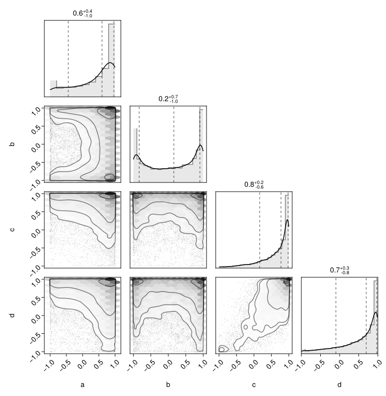

```julia
gtb |> Functional(cos) |> values |> pairplot
```

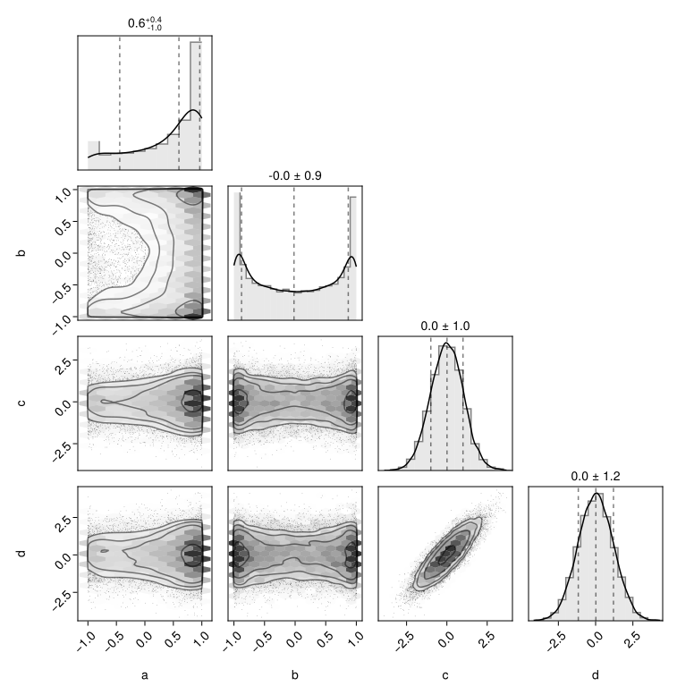

```julia
gtb |> Functional("a" => cos, "b" => sin) |> values |> pairplot
```

The `Map` transform can be used to create new columns from existing columns in the geotable. It takes a column specification, calls a function on the selected columns row-by-row, and returns the result as a new column:

```julia
gtb |> Map("a" => sin, "b" => cos => "cos(b)")
```

9990 rows omitted

| 10000×3 GeoTable over 100×100 CartesianGrid sin_a Continuous [NoUnits] | 10000×3 GeoTable over 100×100 CartesianGrid cos(b) Continuous [NoUnits] | 10000×3 GeoTable over 100×100 CartesianGrid geometry Quadrangle 🖈 Cartesian{NoDatum} |
| --- | --- | --- |
| 0.782739 | -0.996417 | Quadrangle((x: 0.0 m, y: 0.0 m), ..., (x: 0.0 m, y: 1.0 m)) |
| -0.782144 | 0.00981008 | Quadrangle((x: 1.0 m, y: 0.0 m), ..., (x: 1.0 m, y: 1.0 m)) |
| 0.630839 | 0.49713 | Quadrangle((x: 2.0 m, y: 0.0 m), ..., (x: 2.0 m, y: 1.0 m)) |
| -0.787655 | 0.6392 | Quadrangle((x: 3.0 m, y: 0.0 m), ..., (x: 3.0 m, y: 1.0 m)) |
| -0.429287 | 0.99914 | Quadrangle((x: 4.0 m, y: 0.0 m), ..., (x: 4.0 m, y: 1.0 m)) |
| -0.274439 | -0.745534 | Quadrangle((x: 5.0 m, y: 0.0 m), ..., (x: 5.0 m, y: 1.0 m)) |
| -0.134097 | -0.293399 | Quadrangle((x: 6.0 m, y: 0.0 m), ..., (x: 6.0 m, y: 1.0 m)) |
| -0.854646 | -0.84997 | Quadrangle((x: 7.0 m, y: 0.0 m), ..., (x: 7.0 m, y: 1.0 m)) |
| 0.555545 | -0.999141 | Quadrangle((x: 8.0 m, y: 0.0 m), ..., (x: 8.0 m, y: 1.0 m)) |
| -0.691196 | -0.996229 | Quadrangle((x: 9.0 m, y: 0.0 m), ..., (x: 9.0 m, y: 1.0 m)) |
| ⋮ | ⋮ | ⋮ |

```julia
gtb |> Map([2, 3] => ((b, c) -> 2b + c) => "f(b, c)")
```

9990 rows omitted

| 10000×2 GeoTable over 100×100 CartesianGrid f(b, c) Continuous [NoUnits] | 10000×2 GeoTable over 100×100 CartesianGrid geometry Quadrangle 🖈 Cartesian{NoDatum} |
| --- | --- |
| -5.40293 | Quadrangle((x: 0.0 m, y: 0.0 m), ..., (x: 0.0 m, y: 1.0 m)) |
| -10.1211 | Quadrangle((x: 1.0 m, y: 0.0 m), ..., (x: 1.0 m, y: 1.0 m)) |
| -2.10976 | Quadrangle((x: 2.0 m, y: 0.0 m), ..., (x: 2.0 m, y: 1.0 m)) |
| 1.64794 | Quadrangle((x: 3.0 m, y: 0.0 m), ..., (x: 3.0 m, y: 1.0 m)) |
| 0.393384 | Quadrangle((x: 4.0 m, y: 0.0 m), ..., (x: 4.0 m, y: 1.0 m)) |
| -6.81159 | Quadrangle((x: 5.0 m, y: 0.0 m), ..., (x: 5.0 m, y: 1.0 m)) |
| -2.67133 | Quadrangle((x: 6.0 m, y: 0.0 m), ..., (x: 6.0 m, y: 1.0 m)) |
| -18.4207 | Quadrangle((x: 7.0 m, y: 0.0 m), ..., (x: 7.0 m, y: 1.0 m)) |
| 7.44655 | Quadrangle((x: 8.0 m, y: 0.0 m), ..., (x: 8.0 m, y: 1.0 m)) |
| -5.9663 | Quadrangle((x: 9.0 m, y: 0.0 m), ..., (x: 9.0 m, y: 1.0 m)) |
| ⋮ | ⋮ |

The name of the resulting column can be provided or omitted. If the name is omitted like in the example above with the column “a”, it is created by concatenation of column and function names.

To filter rows in the geotable based on a given predicate (i.e., a function that returns `true` or `false`), we can use the `Filter` transform:

```julia
gtb |> Filter(row -> row.a < 0 && row.b > 0)
```

1226 rows omitted

| 1236×5 GeoTable over 1236 view(::CartesianGrid, [3931, 5002, 5004, 5009, ..., 9981, 9983, 9989, 9994]) a Continuous [NoUnits] | 1236×5 GeoTable over 1236 view(::CartesianGrid, [3931, 5002, 5004, 5009, ..., 9981, 9983, 9989, 9994]) b Continuous [NoUnits] | 1236×5 GeoTable over 1236 view(::CartesianGrid, [3931, 5002, 5004, 5009, ..., 9981, 9983, 9989, 9994]) c Continuous [NoUnits] | 1236×5 GeoTable over 1236 view(::CartesianGrid, [3931, 5002, 5004, 5009, ..., 9981, 9983, 9989, 9994]) d Continuous [NoUnits] | 1236×5 GeoTable over 1236 view(::CartesianGrid, [3931, 5002, 5004, 5009, ..., 9981, 9983, 9989, 9994]) geometry Quadrangle 🖈 Cartesian{NoDatum} |
| --- | --- | --- | --- | --- |
| -0.353451 | 3.35344 | 2.08175 | 2.08838 | Quadrangle((x: 30.0 m, y: 39.0 m), ..., (x: 30.0 m, y: 40.0 m)) |
| -1.37136 | 1.11422 | -1.18264 | -0.131473 | Quadrangle((x: 1.0 m, y: 50.0 m), ..., (x: 1.0 m, y: 51.0 m)) |
| -1.99459 | 3.83896 | 0.138539 | -1.58369 | Quadrangle((x: 3.0 m, y: 50.0 m), ..., (x: 3.0 m, y: 51.0 m)) |
| -1.33538 | 2.08931 | 0.541138 | 0.0751396 | Quadrangle((x: 8.0 m, y: 50.0 m), ..., (x: 8.0 m, y: 51.0 m)) |
| -0.584513 | 0.319195 | -0.514335 | 0.540757 | Quadrangle((x: 14.0 m, y: 50.0 m), ..., (x: 14.0 m, y: 51.0 m)) |
| -0.648703 | 0.813813 | -0.588614 | -0.957929 | Quadrangle((x: 15.0 m, y: 50.0 m), ..., (x: 15.0 m, y: 51.0 m)) |
| -0.136635 | 1.84381 | -0.961091 | -1.76851 | Quadrangle((x: 16.0 m, y: 50.0 m), ..., (x: 16.0 m, y: 51.0 m)) |
| -0.564934 | 3.47027 | -1.20279 | -2.00253 | Quadrangle((x: 20.0 m, y: 50.0 m), ..., (x: 20.0 m, y: 51.0 m)) |
| -1.51337 | 0.256306 | -1.03495 | -1.04446 | Quadrangle((x: 22.0 m, y: 50.0 m), ..., (x: 22.0 m, y: 51.0 m)) |
| -0.409511 | 2.37543 | -0.45101 | -0.314136 | Quadrangle((x: 23.0 m, y: 50.0 m), ..., (x: 23.0 m, y: 51.0 m)) |
| ⋮ | ⋮ | ⋮ | ⋮ | ⋮ |

To sort rows based on specific columns we can use the `Sort` transform:

```julia
gtb |> Sort("a", "b")
```

9990 rows omitted

| 10000×5 GeoTable over 10000 view(::CartesianGrid, [9165, 7239, 6452, 9936, ..., 55, 1000, 3361, 3395]) a Continuous [NoUnits] | 10000×5 GeoTable over 10000 view(::CartesianGrid, [9165, 7239, 6452, 9936, ..., 55, 1000, 3361, 3395]) b Continuous [NoUnits] | 10000×5 GeoTable over 10000 view(::CartesianGrid, [9165, 7239, 6452, 9936, ..., 55, 1000, 3361, 3395]) c Continuous [NoUnits] | 10000×5 GeoTable over 10000 view(::CartesianGrid, [9165, 7239, 6452, 9936, ..., 55, 1000, 3361, 3395]) d Continuous [NoUnits] | 10000×5 GeoTable over 10000 view(::CartesianGrid, [9165, 7239, 6452, 9936, ..., 55, 1000, 3361, 3395]) geometry Quadrangle 🖈 Cartesian{NoDatum} |
| --- | --- | --- | --- | --- |
| -3.5308 | -3.06883 | 1.33232 | 1.9273 | Quadrangle((x: 64.0 m, y: 91.0 m), ..., (x: 64.0 m, y: 92.0 m)) |
| -3.39853 | -1.25626 | -1.29924 | -1.69919 | Quadrangle((x: 38.0 m, y: 72.0 m), ..., (x: 38.0 m, y: 73.0 m)) |
| -3.13005 | 1.4205 | 1.81539 | 1.96127 | Quadrangle((x: 51.0 m, y: 64.0 m), ..., (x: 51.0 m, y: 65.0 m)) |
| -3.11106 | 0.639964 | -0.0229633 | -0.0975857 | Quadrangle((x: 35.0 m, y: 99.0 m), ..., (x: 35.0 m, y: 100.0 m)) |
| -3.06395 | -4.10504 | 0.863991 | 0.558142 | Quadrangle((x: 39.0 m, y: 66.0 m), ..., (x: 39.0 m, y: 67.0 m)) |
| -3.03301 | 0.153408 | 0.331511 | -0.0799792 | Quadrangle((x: 45.0 m, y: 56.0 m), ..., (x: 45.0 m, y: 57.0 m)) |
| -3.01509 | -1.40658 | 0.795616 | 0.0244 | Quadrangle((x: 78.0 m, y: 99.0 m), ..., (x: 78.0 m, y: 100.0 m)) |
| -2.99712 | 0.0126891 | 0.679013 | 1.9551 | Quadrangle((x: 70.0 m, y: 51.0 m), ..., (x: 70.0 m, y: 52.0 m)) |
| -2.95487 | -1.21161 | 1.83468 | 1.92637 | Quadrangle((x: 8.0 m, y: 53.0 m), ..., (x: 8.0 m, y: 54.0 m)) |
| -2.92472 | 2.94254 | -1.06104 | -1.75935 | Quadrangle((x: 69.0 m, y: 96.0 m), ..., (x: 69.0 m, y: 97.0 m)) |
| ⋮ | ⋮ | ⋮ | ⋮ | ⋮ |

This transform accepts all options of the `sortperm` function in Julia, including the option to sort in reverse order:

```julia
gtb |> Sort("a", "b", rev=true)
```

9990 rows omitted

| 10000×5 GeoTable over 10000 view(::CartesianGrid, [3395, 3361, 1000, 55, ..., 9936, 6452, 7239, 9165]) a Continuous [NoUnits] | 10000×5 GeoTable over 10000 view(::CartesianGrid, [3395, 3361, 1000, 55, ..., 9936, 6452, 7239, 9165]) b Continuous [NoUnits] | 10000×5 GeoTable over 10000 view(::CartesianGrid, [3395, 3361, 1000, 55, ..., 9936, 6452, 7239, 9165]) c Continuous [NoUnits] | 10000×5 GeoTable over 10000 view(::CartesianGrid, [3395, 3361, 1000, 55, ..., 9936, 6452, 7239, 9165]) d Continuous [NoUnits] | 10000×5 GeoTable over 10000 view(::CartesianGrid, [3395, 3361, 1000, 55, ..., 9936, 6452, 7239, 9165]) geometry Quadrangle 🖈 Cartesian{NoDatum} |
| --- | --- | --- | --- | --- |
| 13.5306 | 3.17031 | 0.750867 | 0.464057 | Quadrangle((x: 94.0 m, y: 33.0 m), ..., (x: 94.0 m, y: 34.0 m)) |
| 12.0518 | 3.58682 | -0.565989 | -0.331201 | Quadrangle((x: 60.0 m, y: 33.0 m), ..., (x: 60.0 m, y: 34.0 m)) |
| 11.9848 | -2.69898 | 0.683775 | 0.393929 | Quadrangle((x: 99.0 m, y: 9.0 m), ..., (x: 99.0 m, y: 10.0 m)) |
| 11.9795 | 2.07079 | 0.632713 | -0.245433 | Quadrangle((x: 54.0 m, y: 0.0 m), ..., (x: 54.0 m, y: 1.0 m)) |
| 11.9584 | -0.74499 | -0.692153 | -1.01386 | Quadrangle((x: 3.0 m, y: 13.0 m), ..., (x: 3.0 m, y: 14.0 m)) |
| 11.9027 | 2.53377 | 0.161781 | 0.313783 | Quadrangle((x: 73.0 m, y: 15.0 m), ..., (x: 73.0 m, y: 16.0 m)) |
| 11.6045 | -0.704492 | -0.514435 | -0.736724 | Quadrangle((x: 60.0 m, y: 42.0 m), ..., (x: 60.0 m, y: 43.0 m)) |
| 11.5987 | 0.447995 | 0.328639 | 0.873722 | Quadrangle((x: 44.0 m, y: 6.0 m), ..., (x: 44.0 m, y: 7.0 m)) |
| 11.5594 | -1.04385 | -1.66626 | -1.84188 | Quadrangle((x: 57.0 m, y: 30.0 m), ..., (x: 57.0 m, y: 31.0 m)) |
| 11.5416 | 0.340138 | 1.39404 | 1.96095 | Quadrangle((x: 89.0 m, y: 47.0 m), ..., (x: 89.0 m, y: 48.0 m)) |
| ⋮ | ⋮ | ⋮ | ⋮ | ⋮ |

### 5.2.2 Cleaning

Some feature transforms are used to clean the data before geostatistical analysis. For example, the `StdNames` transform can be used to standardize variable names that are not very readable due to file format limitations. To illustrate this transform, let’s create a geotable with unreadable variable names:

```julia
utb = gtb |> Select("a" => "aBc De-F", "b" => "b_2 (1)")
```

9990 rows omitted

| 10000×3 GeoTable over 100×100 CartesianGrid aBc De-F Continuous [NoUnits] | 10000×3 GeoTable over 100×100 CartesianGrid b_2 (1) Continuous [NoUnits] | 10000×3 GeoTable over 100×100 CartesianGrid geometry Quadrangle 🖈 Cartesian{NoDatum} |
| --- | --- | --- |
| 2.24254 | -3.22627 | Quadrangle((x: 0.0 m, y: 0.0 m), ..., (x: 0.0 m, y: 1.0 m)) |
| 4.03969 | -4.7222 | Quadrangle((x: 1.0 m, y: 0.0 m), ..., (x: 1.0 m, y: 1.0 m)) |
| 2.45896 | -1.05051 | Quadrangle((x: 2.0 m, y: 0.0 m), ..., (x: 2.0 m, y: 1.0 m)) |
| 5.37619 | 0.877339 | Quadrangle((x: 3.0 m, y: 0.0 m), ..., (x: 3.0 m, y: 1.0 m)) |
| 5.83948 | -0.0414821 | Quadrangle((x: 4.0 m, y: 0.0 m), ..., (x: 4.0 m, y: 1.0 m)) |
| 6.00518 | -3.87105 | Quadrangle((x: 5.0 m, y: 0.0 m), ..., (x: 5.0 m, y: 1.0 m)) |
| 6.14868 | -1.86858 | Quadrangle((x: 6.0 m, y: 0.0 m), ..., (x: 6.0 m, y: 1.0 m)) |
| 5.25832 | -9.97965 | Quadrangle((x: 7.0 m, y: 0.0 m), ..., (x: 7.0 m, y: 1.0 m)) |
| 6.8722 | 3.18306 | Quadrangle((x: 8.0 m, y: 0.0 m), ..., (x: 8.0 m, y: 1.0 m)) |
| 10.1879 | -3.05472 | Quadrangle((x: 9.0 m, y: 0.0 m), ..., (x: 9.0 m, y: 1.0 m)) |
| ⋮ | ⋮ | ⋮ |

We can standardize the names with:

```julia
utb |> StdNames()
```

9990 rows omitted

| 10000×3 GeoTable over 100×100 CartesianGrid ABC_DE_F Continuous [NoUnits] | 10000×3 GeoTable over 100×100 CartesianGrid B_2_1 Continuous [NoUnits] | 10000×3 GeoTable over 100×100 CartesianGrid geometry Quadrangle 🖈 Cartesian{NoDatum} |
| --- | --- | --- |
| 2.24254 | -3.22627 | Quadrangle((x: 0.0 m, y: 0.0 m), ..., (x: 0.0 m, y: 1.0 m)) |
| 4.03969 | -4.7222 | Quadrangle((x: 1.0 m, y: 0.0 m), ..., (x: 1.0 m, y: 1.0 m)) |
| 2.45896 | -1.05051 | Quadrangle((x: 2.0 m, y: 0.0 m), ..., (x: 2.0 m, y: 1.0 m)) |
| 5.37619 | 0.877339 | Quadrangle((x: 3.0 m, y: 0.0 m), ..., (x: 3.0 m, y: 1.0 m)) |
| 5.83948 | -0.0414821 | Quadrangle((x: 4.0 m, y: 0.0 m), ..., (x: 4.0 m, y: 1.0 m)) |
| 6.00518 | -3.87105 | Quadrangle((x: 5.0 m, y: 0.0 m), ..., (x: 5.0 m, y: 1.0 m)) |
| 6.14868 | -1.86858 | Quadrangle((x: 6.0 m, y: 0.0 m), ..., (x: 6.0 m, y: 1.0 m)) |
| 5.25832 | -9.97965 | Quadrangle((x: 7.0 m, y: 0.0 m), ..., (x: 7.0 m, y: 1.0 m)) |
| 6.8722 | 3.18306 | Quadrangle((x: 8.0 m, y: 0.0 m), ..., (x: 8.0 m, y: 1.0 m)) |
| 10.1879 | -3.05472 | Quadrangle((x: 9.0 m, y: 0.0 m), ..., (x: 9.0 m, y: 1.0 m)) |
| ⋮ | ⋮ | ⋮ |

By default the transform, uses the `:uppersnake` naming convention. Other conventions can be specified depending on personal preference:

```julia
utb |> StdNames(:uppercamel)
```

9990 rows omitted

| 10000×3 GeoTable over 100×100 CartesianGrid AbcDeF Continuous [NoUnits] | 10000×3 GeoTable over 100×100 CartesianGrid B21 Continuous [NoUnits] | 10000×3 GeoTable over 100×100 CartesianGrid geometry Quadrangle 🖈 Cartesian{NoDatum} |
| --- | --- | --- |
| 2.24254 | -3.22627 | Quadrangle((x: 0.0 m, y: 0.0 m), ..., (x: 0.0 m, y: 1.0 m)) |
| 4.03969 | -4.7222 | Quadrangle((x: 1.0 m, y: 0.0 m), ..., (x: 1.0 m, y: 1.0 m)) |
| 2.45896 | -1.05051 | Quadrangle((x: 2.0 m, y: 0.0 m), ..., (x: 2.0 m, y: 1.0 m)) |
| 5.37619 | 0.877339 | Quadrangle((x: 3.0 m, y: 0.0 m), ..., (x: 3.0 m, y: 1.0 m)) |
| 5.83948 | -0.0414821 | Quadrangle((x: 4.0 m, y: 0.0 m), ..., (x: 4.0 m, y: 1.0 m)) |
| 6.00518 | -3.87105 | Quadrangle((x: 5.0 m, y: 0.0 m), ..., (x: 5.0 m, y: 1.0 m)) |
| 6.14868 | -1.86858 | Quadrangle((x: 6.0 m, y: 0.0 m), ..., (x: 6.0 m, y: 1.0 m)) |
| 5.25832 | -9.97965 | Quadrangle((x: 7.0 m, y: 0.0 m), ..., (x: 7.0 m, y: 1.0 m)) |
| 6.8722 | 3.18306 | Quadrangle((x: 8.0 m, y: 0.0 m), ..., (x: 8.0 m, y: 1.0 m)) |
| 10.1879 | -3.05472 | Quadrangle((x: 9.0 m, y: 0.0 m), ..., (x: 9.0 m, y: 1.0 m)) |
| ⋮ | ⋮ | ⋮ |

```julia
utb |> StdNames(:upperflat)
```

9990 rows omitted

| 10000×3 GeoTable over 100×100 CartesianGrid ABCDEF Continuous [NoUnits] | 10000×3 GeoTable over 100×100 CartesianGrid B21 Continuous [NoUnits] | 10000×3 GeoTable over 100×100 CartesianGrid geometry Quadrangle 🖈 Cartesian{NoDatum} |
| --- | --- | --- |
| 2.24254 | -3.22627 | Quadrangle((x: 0.0 m, y: 0.0 m), ..., (x: 0.0 m, y: 1.0 m)) |
| 4.03969 | -4.7222 | Quadrangle((x: 1.0 m, y: 0.0 m), ..., (x: 1.0 m, y: 1.0 m)) |
| 2.45896 | -1.05051 | Quadrangle((x: 2.0 m, y: 0.0 m), ..., (x: 2.0 m, y: 1.0 m)) |
| 5.37619 | 0.877339 | Quadrangle((x: 3.0 m, y: 0.0 m), ..., (x: 3.0 m, y: 1.0 m)) |
| 5.83948 | -0.0414821 | Quadrangle((x: 4.0 m, y: 0.0 m), ..., (x: 4.0 m, y: 1.0 m)) |
| 6.00518 | -3.87105 | Quadrangle((x: 5.0 m, y: 0.0 m), ..., (x: 5.0 m, y: 1.0 m)) |
| 6.14868 | -1.86858 | Quadrangle((x: 6.0 m, y: 0.0 m), ..., (x: 6.0 m, y: 1.0 m)) |
| 5.25832 | -9.97965 | Quadrangle((x: 7.0 m, y: 0.0 m), ..., (x: 7.0 m, y: 1.0 m)) |
| 6.8722 | 3.18306 | Quadrangle((x: 8.0 m, y: 0.0 m), ..., (x: 8.0 m, y: 1.0 m)) |
| 10.1879 | -3.05472 | Quadrangle((x: 9.0 m, y: 0.0 m), ..., (x: 9.0 m, y: 1.0 m)) |
| ⋮ | ⋮ | ⋮ |

The `Replace` transform can be used to replace specific values in the geotable by new values that are meaningful to the analysis. For example, we can replace the values `-999` and `NaN` that are used to represent `missing` values in some file formats:

```julia
rtb = georef((a=[1,-999,3], b=[NaN,5,6]))
```

| 3×3 GeoTable over 3 CartesianGrid a Categorical [NoUnits] | 3×3 GeoTable over 3 CartesianGrid b Continuous [NoUnits] | 3×3 GeoTable over 3 CartesianGrid geometry Segment 🖈 Cartesian{NoDatum} |
| --- | --- | --- |
| 1 | NaN | Segment((x: 0.0 m), (x: 1.0 m)) |
| -999 | 5.0 | Segment((x: 1.0 m), (x: 2.0 m)) |
| 3 | 6.0 | Segment((x: 2.0 m), (x: 3.0 m)) |

```julia
rtb |> Replace(-999 => missing, NaN => missing)
```

| 3×3 GeoTable over 3 CartesianGrid a Categorical [NoUnits] | 3×3 GeoTable over 3 CartesianGrid b Continuous [NoUnits] | 3×3 GeoTable over 3 CartesianGrid geometry Segment 🖈 Cartesian{NoDatum} |
| --- | --- | --- |
| 1 | missing | Segment((x: 0.0 m), (x: 1.0 m)) |
| missing | 5.0 | Segment((x: 1.0 m), (x: 2.0 m)) |
| 3 | 6.0 | Segment((x: 2.0 m), (x: 3.0 m)) |

or replace all negative values using a predicate function:

```julia
rtb |> Replace(<(0) => missing)
```

| 3×3 GeoTable over 3 CartesianGrid a Categorical [NoUnits] | 3×3 GeoTable over 3 CartesianGrid b Continuous [NoUnits] | 3×3 GeoTable over 3 CartesianGrid geometry Segment 🖈 Cartesian{NoDatum} |
| --- | --- | --- |
| 1 | NaN | Segment((x: 0.0 m), (x: 1.0 m)) |
| missing | 5.0 | Segment((x: 1.0 m), (x: 2.0 m)) |
| 3 | 6.0 | Segment((x: 2.0 m), (x: 3.0 m)) |

**Note**

In Julia, the expression `<(0)` is equivalent to the predicate function `x -> x < 0`.

Although `Replace` could be used to replace `missing` values by new values, there is a specific transform for this purpose named `Coalesce`:

```julia
ctb = georef((a=[1,missing,3], b=[4,5,6])) |> Coalesce(value=2)
```

| 3×3 GeoTable over 3 CartesianGrid a Categorical [NoUnits] | 3×3 GeoTable over 3 CartesianGrid b Categorical [NoUnits] | 3×3 GeoTable over 3 CartesianGrid geometry Segment 🖈 Cartesian{NoDatum} |
| --- | --- | --- |
| 1 | 4 | Segment((x: 0.0 m), (x: 1.0 m)) |
| 2 | 5 | Segment((x: 1.0 m), (x: 2.0 m)) |
| 3 | 6 | Segment((x: 2.0 m), (x: 3.0 m)) |

**Note**

Unlike `Replace`, the `Coalesce` transform also changes the column type to make sure that no `missing` values can be stored in the future:

```julia
typeof(ctb.a)
```

```
Vector{Int64} (alias for Array{Int64, 1})
```

In many applications, it is enough to simply drop all rows for which the selected column values are `missing`. This is the purpose of the `DropMissing` transform:

```julia
georef((a=[1,missing,3], b=[4,5,6])) |> DropMissing()
```

| 2×3 GeoTable over 2 view(::CartesianGrid, [1, 3]) a Categorical [NoUnits] | 2×3 GeoTable over 2 view(::CartesianGrid, [1, 3]) b Categorical [NoUnits] | 2×3 GeoTable over 2 view(::CartesianGrid, [1, 3]) geometry Segment 🖈 Cartesian{NoDatum} |
| --- | --- | --- |
| 1 | 4 | Segment((x: 0.0 m), (x: 1.0 m)) |
| 3 | 6 | Segment((x: 2.0 m), (x: 3.0 m)) |

The `DropNaN` is an alternative to drop all rows for which the selected column values are `NaN`.

### 5.2.3 Statistical

The framework provides various feature transforms for statistical analysis. We will cover some of these transforms in more detail in **Part V** of the book with real data. In the following examples we illustrate the most basic statistical transforms with synthetic data.

The `Sample` transform can be used to sample rows of the geotable at random, with or without replacement depending on the `replace` option. Other options are available such as `rng` to set the random number generator and `ordered` to preserve the order of rows in the original geotable:

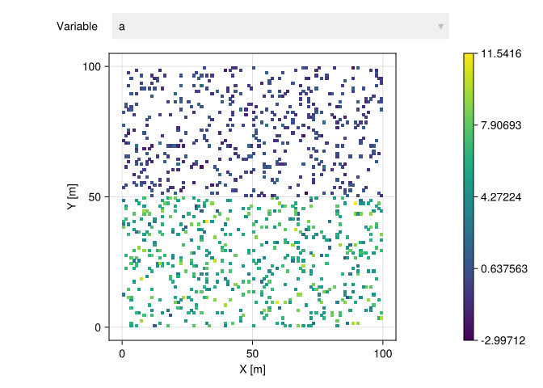

```julia
gtb |> Sample(1000, replace=false) |> viewer
```

**Note**

Similar to `Filter` and `Sort`, the `Sample` transform is lazy. It simply stores the indices of sampled rows for future construction of the new geotable.

The `Center` and `Scale` transforms can be used to standardize the range of values in a geotable. Aliases are provided for specific types of `Scale` such as `MinMax` and `Interquartile`. We can use the `describe` function to visualize basic statistics before and after the transforms:

```julia
gtb |> describe
```

```
Table with 7 columns and 4 rows:
     variable  scitype     mean        minimum   median       maximum  nmissing
   ┌───────────────────────────────────────────────────────────────────────────
 1 │ a         Continuous  2.97614     -3.5308   1.9871       13.5306  0
 2 │ b         Continuous  0.0180558   -11.1294  -0.00986202  10.1208  0
 3 │ c         Continuous  0.00696635  -3.88874  0.00814772   3.70154  0
 4 │ d         Continuous  0.0143627   -4.16164  0.0169899    4.32637  0
```

```julia
gtb |> Center("a") |> describe
```

```
Table with 7 columns and 4 rows:
     variable  scitype     mean          minimum   median       maximum  ⋯
   ┌──────────────────────────────────────────────────────────────────────
 1 │ a         Continuous  -1.81899e-16  -6.50694  -0.989043    10.5544  ⋯
 2 │ b         Continuous  0.0180558     -11.1294  -0.00986202  10.1208  ⋯
 3 │ c         Continuous  0.00696635    -3.88874  0.00814772   3.70154  ⋯
 4 │ d         Continuous  0.0143627     -4.16164  0.0169899    4.32637  ⋯
```

```julia
gtb |> MinMax() |> describe
```

```
Table with 7 columns and 4 rows:
     variable  scitype     mean      minimum  median    maximum  nmissing
   ┌─────────────────────────────────────────────────────────────────────
 1 │ a         Continuous  0.381385  0.0      0.323415  1.0      0
 2 │ b         Continuous  0.524582  0.0      0.523269  1.0      0
 3 │ c         Continuous  0.51325   0.0      0.513405  1.0      0
 4 │ d         Continuous  0.491989  0.0      0.492298  1.0      0
```

The `ZScore` transform is similar to the `Scale` transform, but it uses the mean and the standard deviation to standardize the range:

```julia
gtb |> ZScore() |> describe
```

```
Table with 7 columns and 4 rows:
     variable  scitype     mean          minimum   median      maximum  nmissing
   ┌────────────────────────────────────────────────────────────────────────────
 1 │ a         Continuous  -1.36424e-15  -1.93541  -0.294179   3.13929  0
 2 │ b         Continuous  2.55795e-17   -4.35673  -0.010911   3.94842  0
 3 │ c         Continuous  -3.12639e-17  -3.85218  0.00116818  3.65329  0
 4 │ d         Continuous  4.40536e-17   -3.53708  0.0022252   3.65227  0
```

Another important univariate transform is the `Quantile` transform, which can be used to convert empirical distribution in a column of the geotable to any given distribution from Distributions.jl by Lin et al. (2023). Selected columns are converted to a `Normal` distribution by default, but more than 60 distributions are available:

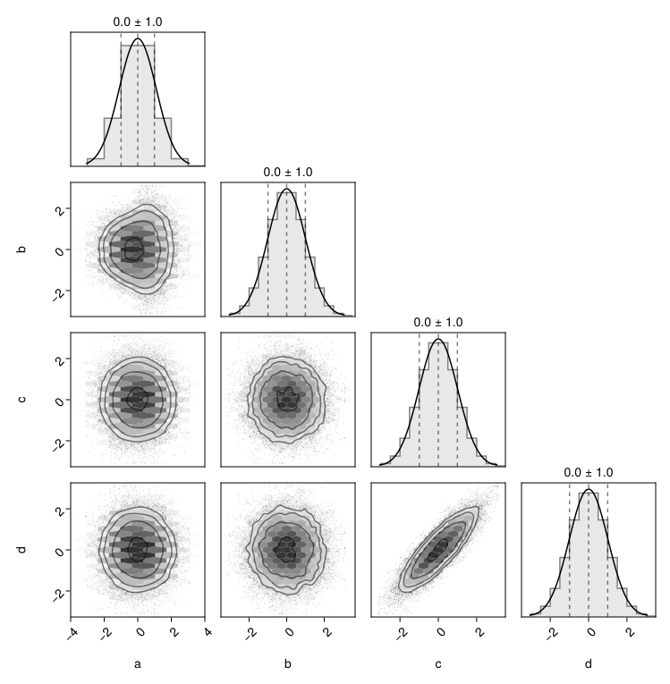

```julia
gtb |> Quantile() |> values |> pairplot
```

In data science, scientific traits are used to link data types to adequate statistical algorithms. The most popular scientific traits encountered in geoscientific applications are the `Continuous` and the `Categorical` scientific traits. To convert (or coerce) the scientific traits of columns in a geotable, we can use the `Coerce` transform:

```julia
stb = georef((a=[1,2,2,2,3,3], b=[1,2,3,4,5,6])) |> Coerce("b" => Continuous)
```

| 6×3 GeoTable over 6 CartesianGrid a Categorical [NoUnits] | 6×3 GeoTable over 6 CartesianGrid b Continuous [NoUnits] | 6×3 GeoTable over 6 CartesianGrid geometry Segment 🖈 Cartesian{NoDatum} |
| --- | --- | --- |
| 1 | 1.0 | Segment((x: 0.0 m), (x: 1.0 m)) |
| 2 | 2.0 | Segment((x: 1.0 m), (x: 2.0 m)) |
| 2 | 3.0 | Segment((x: 2.0 m), (x: 3.0 m)) |
| 2 | 4.0 | Segment((x: 3.0 m), (x: 4.0 m)) |
| 3 | 5.0 | Segment((x: 4.0 m), (x: 5.0 m)) |
| 3 | 6.0 | Segment((x: 5.0 m), (x: 6.0 m)) |

```julia
eltype(stb.b)
```

```
Float64
```

**Note**

All scientific traits are documented in the DataScienceTraits.jl module, and can be used to select variables:

```julia
stb |> Only(Continuous)
```

| 6×2 GeoTable over 6 CartesianGrid b Continuous [NoUnits] | 6×2 GeoTable over 6 CartesianGrid geometry Segment 🖈 Cartesian{NoDatum} |
| --- | --- |
| 1.0 | Segment((x: 0.0 m), (x: 1.0 m)) |
| 2.0 | Segment((x: 1.0 m), (x: 2.0 m)) |
| 3.0 | Segment((x: 2.0 m), (x: 3.0 m)) |
| 4.0 | Segment((x: 3.0 m), (x: 4.0 m)) |
| 5.0 | Segment((x: 4.0 m), (x: 5.0 m)) |
| 6.0 | Segment((x: 5.0 m), (x: 6.0 m)) |

The `Levels` transform can be used to adjust the categories (or levels) of `Categorical` columns in case the sampling process does not include all possible values:

```julia
stb = stb |> Levels("a" => [1,2,3,4])
```

| 6×3 GeoTable over 6 CartesianGrid a Categorical [NoUnits] | 6×3 GeoTable over 6 CartesianGrid b Continuous [NoUnits] | 6×3 GeoTable over 6 CartesianGrid geometry Segment 🖈 Cartesian{NoDatum} |
| --- | --- | --- |
| CategoricalValue(CategoricalArrays.CategoricalPool{Int64, UInt32}([1, 2, 3, 4]), 1) | 1.0 | Segment((x: 0.0 m), (x: 1.0 m)) |
| CategoricalValue(CategoricalArrays.CategoricalPool{Int64, UInt32}([1, 2, 3, 4]), 2) | 2.0 | Segment((x: 1.0 m), (x: 2.0 m)) |
| CategoricalValue(CategoricalArrays.CategoricalPool{Int64, UInt32}([1, 2, 3, 4]), 2) | 3.0 | Segment((x: 2.0 m), (x: 3.0 m)) |
| CategoricalValue(CategoricalArrays.CategoricalPool{Int64, UInt32}([1, 2, 3, 4]), 2) | 4.0 | Segment((x: 3.0 m), (x: 4.0 m)) |
| CategoricalValue(CategoricalArrays.CategoricalPool{Int64, UInt32}([1, 2, 3, 4]), 3) | 5.0 | Segment((x: 4.0 m), (x: 5.0 m)) |
| CategoricalValue(CategoricalArrays.CategoricalPool{Int64, UInt32}([1, 2, 3, 4]), 3) | 6.0 | Segment((x: 5.0 m), (x: 6.0 m)) |

```julia
levels(stb.a)
```

```
4-element CategoricalArrays.CategoricalArray{Int64,1,UInt32}:
 1
 2
 3
 4
```

Another popular transform in statistical learning is the `OneHot` transform. It converts a `Categorical` column into multiple columns of `true`/`false` values, one column for each level:

```julia
stb |> OneHot("a")
```

| 6×6 GeoTable over 6 CartesianGrid a_1 Categorical [NoUnits] | 6×6 GeoTable over 6 CartesianGrid a_2 Categorical [NoUnits] | 6×6 GeoTable over 6 CartesianGrid a_3 Categorical [NoUnits] | 6×6 GeoTable over 6 CartesianGrid a_4 Categorical [NoUnits] | 6×6 GeoTable over 6 CartesianGrid b Continuous [NoUnits] | 6×6 GeoTable over 6 CartesianGrid geometry Segment 🖈 Cartesian{NoDatum} |
| --- | --- | --- | --- | --- | --- |
| true | false | false | false | 1.0 | Segment((x: 0.0 m), (x: 1.0 m)) |
| false | true | false | false | 2.0 | Segment((x: 1.0 m), (x: 2.0 m)) |
| false | true | false | false | 3.0 | Segment((x: 2.0 m), (x: 3.0 m)) |
| false | true | false | false | 4.0 | Segment((x: 3.0 m), (x: 4.0 m)) |
| false | false | true | false | 5.0 | Segment((x: 4.0 m), (x: 5.0 m)) |
| false | false | true | false | 6.0 | Segment((x: 5.0 m), (x: 6.0 m)) |

A similar transform for `Continuous` columns is the `Indicator` transform. It converts the column into multiple columns based on threshold values on the support of the data. By default, the threshold values are computed on a quantile `scale`:

```julia
stb |> Indicator("b", k=3, scale=:quantile)
```

| 6×5 GeoTable over 6 CartesianGrid a Categorical [NoUnits] | 6×5 GeoTable over 6 CartesianGrid b_1 Categorical [NoUnits] | 6×5 GeoTable over 6 CartesianGrid b_2 Categorical [NoUnits] | 6×5 GeoTable over 6 CartesianGrid b_3 Categorical [NoUnits] | 6×5 GeoTable over 6 CartesianGrid geometry Segment 🖈 Cartesian{NoDatum} |
| --- | --- | --- | --- | --- |
| CategoricalValue(CategoricalArrays.CategoricalPool{Int64, UInt32}([1, 2, 3, 4]), 1) | true | true | true | Segment((x: 0.0 m), (x: 1.0 m)) |
| CategoricalValue(CategoricalArrays.CategoricalPool{Int64, UInt32}([1, 2, 3, 4]), 2) | true | true | true | Segment((x: 1.0 m), (x: 2.0 m)) |
| CategoricalValue(CategoricalArrays.CategoricalPool{Int64, UInt32}([1, 2, 3, 4]), 2) | false | true | true | Segment((x: 2.0 m), (x: 3.0 m)) |
| CategoricalValue(CategoricalArrays.CategoricalPool{Int64, UInt32}([1, 2, 3, 4]), 2) | false | true | true | Segment((x: 3.0 m), (x: 4.0 m)) |
| CategoricalValue(CategoricalArrays.CategoricalPool{Int64, UInt32}([1, 2, 3, 4]), 3) | false | false | true | Segment((x: 4.0 m), (x: 5.0 m)) |
| CategoricalValue(CategoricalArrays.CategoricalPool{Int64, UInt32}([1, 2, 3, 4]), 3) | false | false | true | Segment((x: 5.0 m), (x: 6.0 m)) |

More advanced statistical transforms such as `EigenAnalysis`, `PCA`, `DRS`, `SDS`, `ProjectionPursuit` for multivariate data analysis and `Remainder`, `Closure`, `LogRatio`, `ALR`, `CLR`, `ILR` for compositional data analysis will be covered in future chapters.

## 5.3 Geometric transforms

While feature transforms operate on the `values` of the geotable, geometric transforms operate on the geospatial `domain`. The framework provides various geometric transforms for 2D and 3D space.

### 5.3.1 Coordinate

A coordinate transform is a geometric transform that modifies the coordinates of all points in the domain without any advanced topological modification (i.e., connectivities are preserved). The most prominent examples of coordinate transforms are `Translate`, `Rotate` and `Scale`.

Let’s load an additional geotable to see these transforms in action:

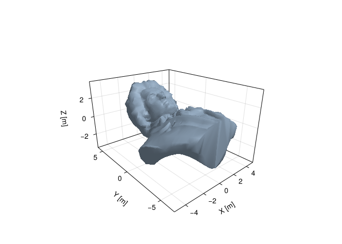

```julia
using GeoIO

btb = GeoIO.load("data/beethoven.ply")

viz(btb.geometry)
```

The Beethoven domain has been saved in the `.ply` file in a position that is not ideal for visualization. We can rotate this domain with any active rotation specification from Rotations.jl by Koolen et al. (2023) to improve the visualization. For example, we can specify that we want to rotate all points in the mesh by analogy with a rotation between coordinates `(0, 1, 0)` and coordinates `(0, 0, 1)`:

[figure not shown]

```julia
rtb = btb |> Rotate((0, 1, 0), (0, 0, 1))

viz(rtb.geometry)
```

Beethoven is now standing up, but still facing the wall. Let’s rotate it once again by analogy between coordinates `(1, 0, 0)` and `(-1, 1, 0)`:

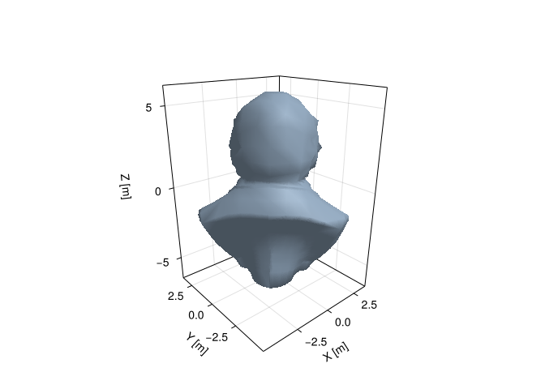

```julia
rtb = rtb |> Rotate((1, 0, 0), (-1, 1, 0))

viz(rtb.geometry)
```

Rotation specifications are also available in 2D space. As an example, we can rotate the 2D grid of our synthetic geotable by the counter clockwise angle `π/4`:

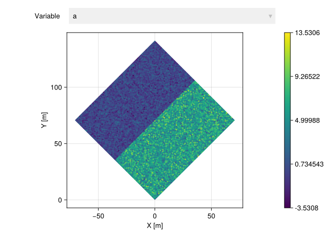

```julia
gtb |> Rotate(Angle2d(π/4)) |> viewer
```

In GIS, this new geotable would be called a rotated “raster”. As another example, let’s translate the geotable to the origin of the coordinate system with the `Translate` transform:

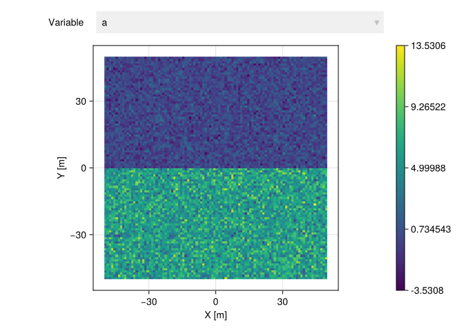

```julia
c = centroid(gtb.geometry)

gtb |> Translate(-to(c)...) |> viewer
```

and scale it with a positive factor for each dimension:

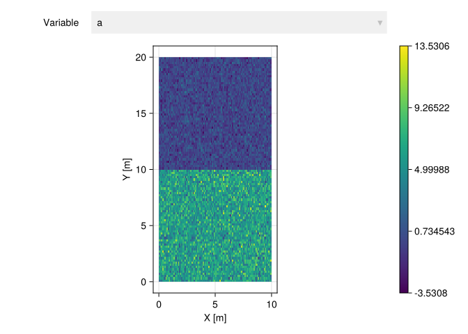

```julia
gtb |> Scale(0.1, 0.2) |> viewer
```

The `StdCoords` transform combines `Translate` and `Scale` to standardize the coordinates of the domain to the interval `[-0.5, 0.5]`:

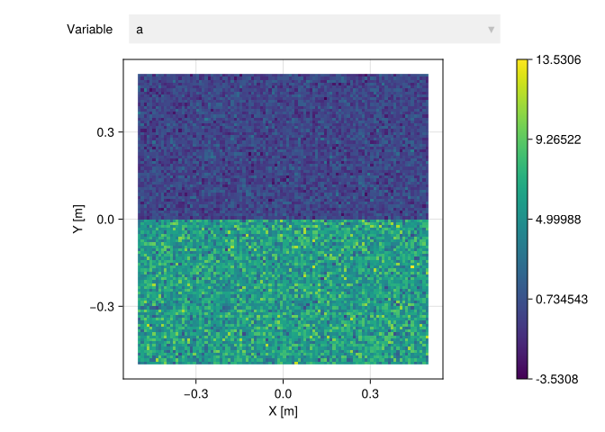

```julia
gtb |> StdCoords() |> viewer
```

In GIS, another very important coordinate transform is the `Proj` transform. We will cover this transform in the next chapter because it depends on the concept of [map projection](https://en.wikipedia.org/wiki/Map_projection), which deserves more attention.

**Note**

In our framework, the `Proj` transform is just another coordinate transform. It is implemented with the same code optimizations, and can be used in conjunction with many other transforms that are not available elsewhere.

### 5.3.2 Advanced

Advanced geometric transforms are provided that change the topology of the `domain` besides the coordinates of points. Some of these transforms can be useful to repair problematic geometries acquired from sensors in the real world.

The `Repair` transform is parameterized by an integer `K` that identifies the repair to be performed. For example, `Repair{0}()` is a transform that removes duplicated vertices and faces in a domain represented by a mesh. The `Repair{9}()` on the other hand fixes the orientation of rings in polygonal areas so that the external boundary is oriented counter clockwise and the inner boundaries are oriented clockwise. The list of available repairs will continue to grow with the implementation of new geometric algorithms in the framework.

To understand why geometric transforms are more general than coordinate transforms, let’s consider the following polygonal area with holes:

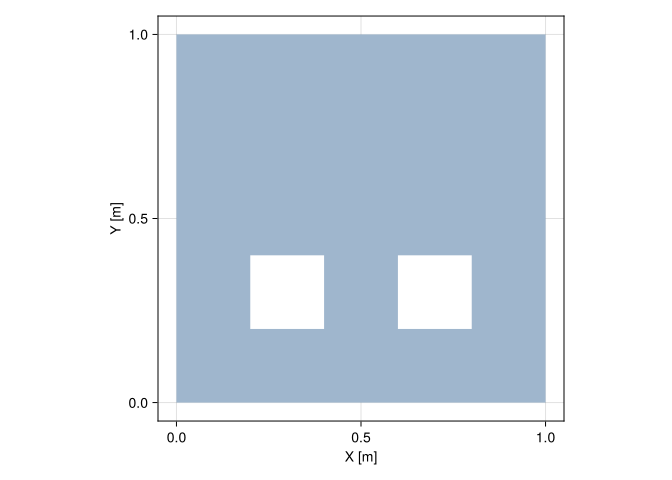

```julia
outer = [(0.0, 0.0), (1.0, 0.0), (1.0, 1.0), (0.0, 1.0)]
hole1 = [(0.2, 0.2), (0.2, 0.4), (0.4, 0.4), (0.4, 0.2)]
hole2 = [(0.6, 0.2), (0.6, 0.4), (0.8, 0.4), (0.8, 0.2)]
poly  = Pgon([outer, hole1, hole2])

viz(poly)
```

We can connect the holes with the external boundary (or ring) using the `Bridge` transform:

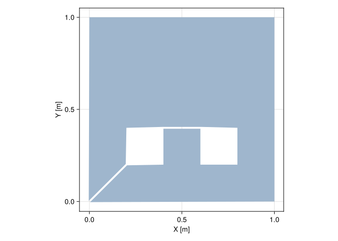

```julia
poly |> Bridge(0.01) |> viz
```

By looking at the visualization, we observe that the number of vertices changed to accommodate the so called “bridges” between the rings. The topology also changed as there are no holes in the resulting geometry.

As a final example of advanced geometric transform, we illustrate the `TaubinSmoothing` transform, which gradually removes sharp boundaries of a manifold mesh:

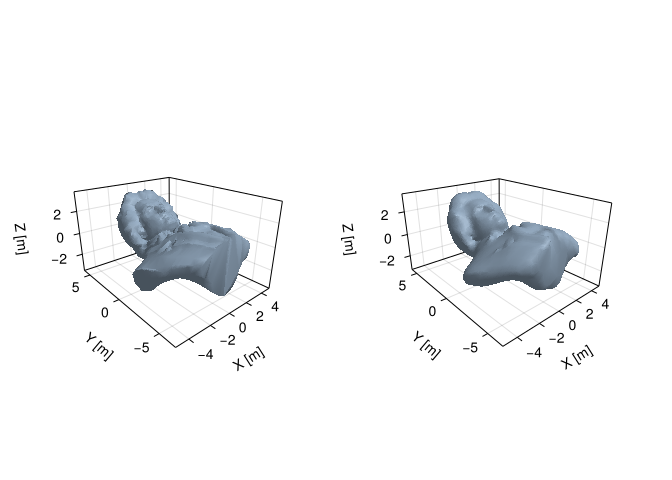

```julia
stb = btb |> TaubinSmoothing(30)

fig = Mke.Figure()
viz(fig[1,1], btb.geometry)
viz(fig[1,2], stb.geometry)
fig
```

For more advanced geometric transforms, please consult the official documentation.

## 5.4 Geospatial transforms

Geospatial transforms are those transforms that operate on both the `values` **and** the `domain` of the geotable. They are common in geostatistical workflows that need to remove geospatial “trends” or workflows that need to extract geometries from domains.

As an example, let’s consider the following geotable with a variable `z` that made of a trend component `μ` and a noise component `ϵ`:

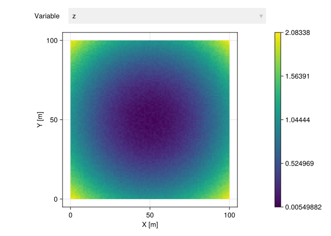

```julia
# quadratic + noise
r = range(-1, stop=1, length=100)
μ = [x^2 + y^2 for x in r, y in r]
ϵ = 0.1rand(100, 100)
t = georef((z=μ+ϵ,))

viewer(t)
```

We can use the `Detrend` transform to remove a trend of polynomial degree `2`:

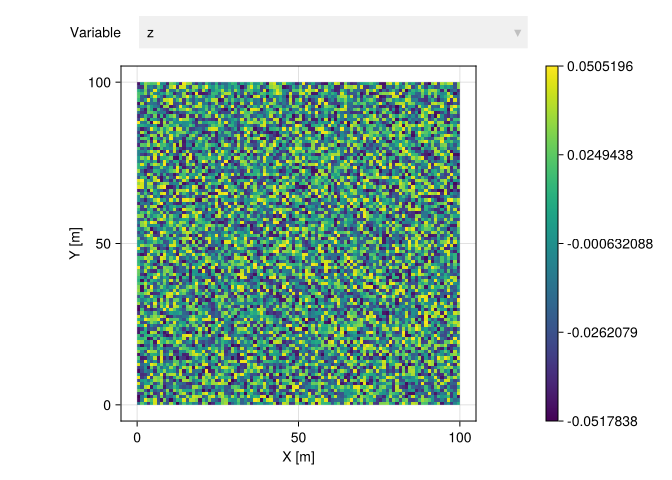

```julia
t |> Detrend(degree=2) |> viewer
```

The remaining component can then be modeled with geostatistical models of geospatial correlation, which will be covered in **Part IV** of the book.

Models of geospatial correlation such as variograms (Hoffimann and Zadrozny 2019) require unique coordinates in the geotable and that is the purpose of the `UniqueCoords` transform. It removes duplicate points in the geotable and aggregates the `values` with custom aggregation functions.

Let’s consider the following geotable stored in a `.png` file to illustrate another geospatial transform:

```julia
letters = GeoIO.load("data/letters.png")
```

44245 rows omitted

| 44255×2 GeoTable over 265×167 TransformedGrid color Colorful [NoUnits] | 44255×2 GeoTable over 265×167 TransformedGrid geometry Quadrangle 🖈 Cartesian{NoDatum} |
| --- | --- |
| Gray{N0f8}(1.0) | Quadrangle((x: -1.62266e-14 m, y: 265.0 m), ..., (x: 1.0 m, y: 265.0 m)) |
| Gray{N0f8}(1.0) | Quadrangle((x: -1.61653e-14 m, y: 264.0 m), ..., (x: 1.0 m, y: 264.0 m)) |
| Gray{N0f8}(1.0) | Quadrangle((x: -1.61041e-14 m, y: 263.0 m), ..., (x: 1.0 m, y: 263.0 m)) |
| Gray{N0f8}(1.0) | Quadrangle((x: -1.60429e-14 m, y: 262.0 m), ..., (x: 1.0 m, y: 262.0 m)) |
| Gray{N0f8}(1.0) | Quadrangle((x: -1.59816e-14 m, y: 261.0 m), ..., (x: 1.0 m, y: 261.0 m)) |
| Gray{N0f8}(1.0) | Quadrangle((x: -1.59204e-14 m, y: 260.0 m), ..., (x: 1.0 m, y: 260.0 m)) |
| Gray{N0f8}(1.0) | Quadrangle((x: -1.58592e-14 m, y: 259.0 m), ..., (x: 1.0 m, y: 259.0 m)) |
| Gray{N0f8}(1.0) | Quadrangle((x: -1.57979e-14 m, y: 258.0 m), ..., (x: 1.0 m, y: 258.0 m)) |
| Gray{N0f8}(1.0) | Quadrangle((x: -1.57367e-14 m, y: 257.0 m), ..., (x: 1.0 m, y: 257.0 m)) |
| Gray{N0f8}(1.0) | Quadrangle((x: -1.56755e-14 m, y: 256.0 m), ..., (x: 1.0 m, y: 256.0 m)) |
| ⋮ | ⋮ |

The `Potrace` transform can be used to extract complex geometries from a geotable over a 2D `Grid`. It transforms the `Grid` domain into a `GeometrySet` based on any column that contains a discrete set of marker values. In this example, we use the `color` as the column with markers:

```julia
Ab = letters |> Potrace("color", ϵ=0.8)
```

| 2×2 GeoTable over 2 GeometrySet color Colorful [NoUnits] | 2×2 GeoTable over 2 GeometrySet geometry MultiPolygon 🖈 Cartesian{NoDatum} |
| --- | --- |
| Gray{N0f8}(1.0) | Multi(4×Pgon) |
| Gray{N0f8}(0.0) | Multi(2×Pgon) |

The option `ϵ` controls the deviation tolerance used to simplify the boundaries of the geometries. The higher is the tolerance, the less is the number of segments in the boundary:

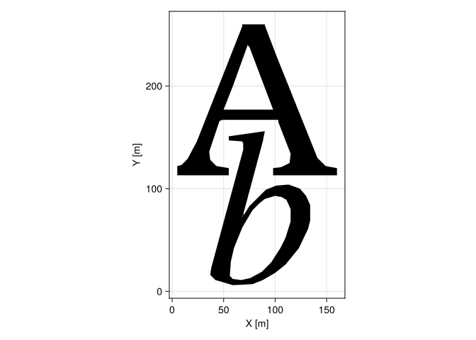

```julia
viz(Ab.geometry[2], color = "black")
```

In the reverse direction, we have the `Rasterize` transform, which takes a geotable over a `GeometrySet` and assigns the geometries to a `Grid`. In this transform, we can either provide an external grid for the the assignments, or request a grid size to discretize the `boundingbox` of all geometries:

```julia
A = [1, 2, 3, 4, 5]
B = [1.1, 2.2, 3.3, 4.4, 5.5]
p1 = Triangle((2, 0), (6, 2), (2, 2))
p2 = Triangle((0, 6), (3, 8), (0, 10))
p3 = Quadrangle((3, 6), (9, 6), (9, 9), (6, 9))
p4 = Quadrangle((7, 0), (10, 0), (10, 4), (7, 4))
p5 = Pentagon((1, 3), (5, 3), (6, 6), (3, 8), (0, 6))
gtb = georef((; A, B), [p1, p2, p3, p4, p5])
```

| 5×3 GeoTable over 5 GeometrySet A Categorical [NoUnits] | 5×3 GeoTable over 5 GeometrySet B Continuous [NoUnits] | 5×3 GeoTable over 5 GeometrySet geometry Ngon 🖈 Cartesian{NoDatum} |
| --- | --- | --- |
| 1 | 1.1 | Triangle((x: 2.0 m, y: 0.0 m), (x: 6.0 m, y: 2.0 m), (x: 2.0 m, y: 2.0 m)) |
| 2 | 2.2 | Triangle((x: 0.0 m, y: 6.0 m), (x: 3.0 m, y: 8.0 m), (x: 0.0 m, y: 10.0 m)) |
| 3 | 3.3 | Quadrangle((x: 3.0 m, y: 6.0 m), ..., (x: 6.0 m, y: 9.0 m)) |
| 4 | 4.4 | Quadrangle((x: 7.0 m, y: 0.0 m), ..., (x: 7.0 m, y: 4.0 m)) |
| 5 | 5.5 | Pentagon((x: 1.0 m, y: 3.0 m), ..., (x: 0.0 m, y: 6.0 m)) |

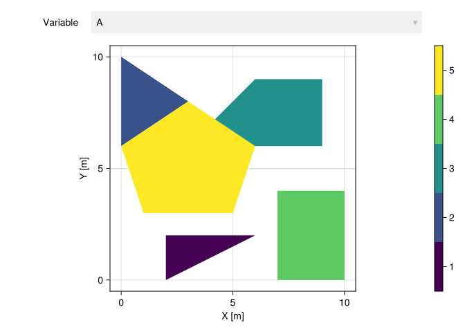

```julia
gtb |> viewer
```

```julia
ntb = gtb |> Rasterize(20, 20)
```

390 rows omitted

| 400×3 GeoTable over 20×20 CartesianGrid A Categorical [NoUnits] | 400×3 GeoTable over 20×20 CartesianGrid B Continuous [NoUnits] | 400×3 GeoTable over 20×20 CartesianGrid geometry Quadrangle 🖈 Cartesian{NoDatum} |
| --- | --- | --- |
| missing | missing | Quadrangle((x: 0.0 m, y: 0.0 m), ..., (x: 0.0 m, y: 0.5 m)) |
| missing | missing | Quadrangle((x: 0.5 m, y: 0.0 m), ..., (x: 0.5 m, y: 0.5 m)) |
| missing | missing | Quadrangle((x: 1.0 m, y: 0.0 m), ..., (x: 1.0 m, y: 0.5 m)) |
| 1 | 1.1 | Quadrangle((x: 1.5 m, y: 0.0 m), ..., (x: 1.5 m, y: 0.5 m)) |
| 1 | 1.1 | Quadrangle((x: 2.0 m, y: 0.0 m), ..., (x: 2.0 m, y: 0.5 m)) |
| missing | missing | Quadrangle((x: 2.5 m, y: 0.0 m), ..., (x: 2.5 m, y: 0.5 m)) |
| missing | missing | Quadrangle((x: 3.0 m, y: 0.0 m), ..., (x: 3.0 m, y: 0.5 m)) |
| missing | missing | Quadrangle((x: 3.5 m, y: 0.0 m), ..., (x: 3.5 m, y: 0.5 m)) |
| missing | missing | Quadrangle((x: 4.0 m, y: 0.0 m), ..., (x: 4.0 m, y: 0.5 m)) |
| missing | missing | Quadrangle((x: 4.5 m, y: 0.0 m), ..., (x: 4.5 m, y: 0.5 m)) |
| ⋮ | ⋮ | ⋮ |

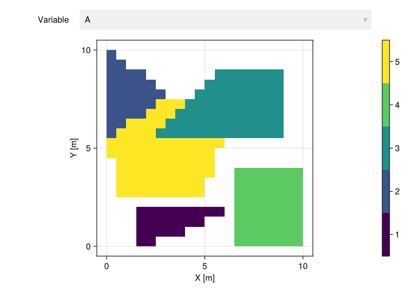

```julia
ntb |> viewer
```

The values of the variables are aggregated at geometric intersections using a default aggregation function, which can be overwritten with an option. Once the geotable is defined over a `Grid`, it is possible to refine or coarsen the grid with the `Downscale` and `Upscale` transforms.

The `Transfer` of values to a new geospatial domain is another very useful geospatial transform. The `Aggregate` transform is related, but aggregates the values with given aggregation functions.

## 5.5 Remarks

In this chapter we learned the important concept of **transforms**, and saw examples of the concept in action with synthetic data. In order to leverage the large number of transforms implemented in the framework, all we need to do is load our geospatial data as a geotable using `georef` or GeoIO.jl.

Some additional remarks:

- One of the major advantages of transforms compared to traditional row/column access in data science is that they **preserve geospatial information**. There is no need to keep track of indices in arrays to repeatedly reattach values to geometries.
- Transforms can be organized into three classes—feature, geometric and geospatial—depending on how they operate with the `values` and the `domain` of the geotable:
  - **Feature** transforms operate on the `values`. They include column selection, data cleaning, statistical analysis and any transform designed for traditional Tables.jl.
  - **Geometric** transforms operate on the `domain`. They include coordinate transforms that simply modify the coordinates of points as well as more advanced transforms that can change the topology of the domain.
  - **Geospatial** transforms operate on both the `values` and `domain`. They include geostatistical transforms and transforms that use other columns besides the `geometry` column to produce new columns and geometries.

In the next chapters, we will review map projections with the `Proj` coordinate transform, and will introduce one of the greatest features of the framework known as **transform pipelines**.

Hoffimann, Júlio, and Bianca Zadrozny. 2019. “Efficient Variography with Partition Variograms.” *Computers & Geosciences* 131: 52–59. https://doi.org/https://doi.org/10.1016/j.cageo.2019.06.013.

Koolen, Twan, Yuto Horikawa, Andy Ferris, et al. 2023. *JuliaGeometry/Rotations.jl: V1.6.0*. V. v1.6.0. Zenodo, released September. https://doi.org/10.5281/zenodo.8366010.

Lin, Dahua, David Widmann, Simon Byrne, et al. 2023. *JuliaStats/Distributions.jl: V0.25.100*. V. v0.25.100. Zenodo, released August. https://doi.org/10.5281/zenodo.8224988.

Thompson, William. 2023. *PairPlots.jl Beautiful and Flexible Visualizations of High Dimensional Data*. [Https://sefffal.github.io/PairPlots.jl/dev](https://sefffal.github.io/PairPlots.jl/dev).